# Project - SARIMA

```python
import pandas as pd
import numpy as np
from statsmodels.tsa.seasonal import seasonal_decompose
import matplotlib.pyplot as plt
from statsmodels.tsa.statespace.sarimax import SARIMAX
from pmdarima import auto_arima
from sklearn.metrics import mean_squared_error
import pickle
import seaborn as sns
from scipy.stats import zscore
```

```python
import warnings
warnings.filterwarnings('ignore')
```

## Load and Clean Data

```python
data = pd.read_csv('traffic.csv')
data.head()
```

|  | DateTime | Junction | Vehicles | ID |
| --- | --- | --- | --- | --- |
| 0 | 2015-11-01 00:00:00 | 1 | 15 | 20151101001 |
| 1 | 2015-11-01 01:00:00 | 1 | 13 | 20151101011 |
| 2 | 2015-11-01 02:00:00 | 1 | 10 | 20151101021 |
| 3 | 2015-11-01 03:00:00 | 1 | 7 | 20151101031 |
| 4 | 2015-11-01 04:00:00 | 1 | 9 | 20151101041 |

```python
data.dtypes
```

```
DateTime    object
Junction     int64
Vehicles     int64
ID           int64
dtype: object
```

```python
# Convert the 'DateTime' column to datetime type and set it as index
data['DateTime'] = pd.to_datetime(data['DateTime'])
data.set_index('DateTime', inplace=True)

data = data.interpolate(method='time')
```

```python
data['z_scores'] = zscore(data['Vehicles'])

# Identify outliers based on a z-score threshold, e.g., z > 3 or z < -3
outliers = data[(data['z_scores'] > 3) | (data['z_scores'] < -3)].index

# Replace outliers - you can replace with NaN, mean, median, etc., depending on your needs
data.loc[outliers, 'Vehicles'] = np.nan  # Example: replacing with NaN
data['Vehicles'].fillna(data['Vehicles'].median(), inplace=True)  # Replace NaN with median

# Drop the z_scores column as it's no longer needed after replacing
data.drop('z_scores', axis=1, inplace=True)

data['Log Vehicles'] = np.log(data['Vehicles'])
data['Diff Log Vehicles'] = data['Log Vehicles'].diff()
#data = data.iloc[1:]
data.head()
```

| DateTime | Junction | Vehicles | ID | Log Vehicles | Diff Log Vehicles |
| --- | --- | --- | --- | --- | --- |
| 2015-11-01 00:00:00 | 1 | 15.0 | 20151101001 | 2.708050 | NaN |
| 2015-11-01 01:00:00 | 1 | 13.0 | 20151101011 | 2.564949 | -0.143101 |
| 2015-11-01 02:00:00 | 1 | 10.0 | 20151101021 | 2.302585 | -0.262364 |
| 2015-11-01 03:00:00 | 1 | 7.0 | 20151101031 | 1.945910 | -0.356675 |
| 2015-11-01 04:00:00 | 1 | 9.0 | 20151101041 | 2.197225 | 0.251314 |

## Data Summary

```python
data.info()
```

[output not shown]

```python
data.describe(include='all')
```

|  | Junction | Vehicles | ID | Log Vehicles | Diff Log Vehicles |
| --- | --- | --- | --- | --- | --- |
| count | 48119.000000 | 48119.000000 | 4.811900e+04 | 48119.000000 | 48118.000000 |
| mean | 2.180573 | 22.791496 | 2.016330e+10 | 2.772402 | -0.000002 |
| std | 0.966950 | 20.750248 | 5.944655e+06 | 0.849212 | 0.307383 |
| min | 1.000000 | 1.000000 | 2.015110e+10 | 0.000000 | -2.564949 |
| 25% | 1.000000 | 9.000000 | 2.016042e+10 | 2.197225 | -0.150823 |
| 50% | 2.000000 | 15.000000 | 2.016093e+10 | 2.708050 | 0.000000 |
| 75% | 3.000000 | 29.000000 | 2.017023e+10 | 3.367296 | 0.149532 |
| max | 4.000000 | 180.000000 | 2.017063e+10 | 5.192957 | 2.602690 |

```python
# Check for missing values in the dataset
missing_values = data.isnull().sum()

# Check for duplicates in the dataset
duplicates = data.duplicated().sum()

print("Missing Values:")
print(missing_values)
print("\nDuplicate rows:", duplicates)
```

```
Missing Values:
Junction             0
Vehicles             0
ID                   0
Log Vehicles         0
Diff Log Vehicles    1
dtype: int64

Duplicate rows: 0
```

## Simple EDA

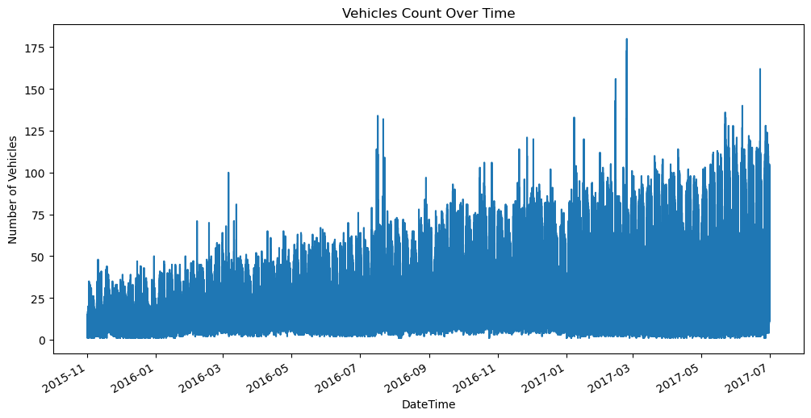

```python
plt.figure(figsize=(12, 6))
data['Vehicles'].plot(title = 'Vehicles Count Over Time')
plt.ylabel('Number of Vehicles')
plt.show()
```

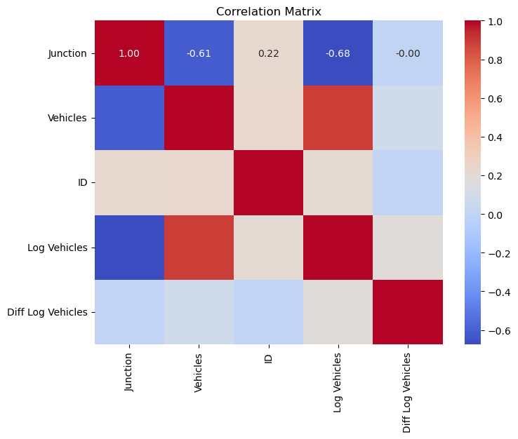

```python
correlation_matrix = data.corr()
plt.figure(figsize=(8, 6))
sns.heatmap(correlation_matrix, annot=True, cmap='coolwarm', fmt=".2f")
plt.title('Correlation Matrix')
plt.show()
```

The correlation matrix reveals a modest correlation between the Junction and Vehicles (-0.61), suggesting that different junctions might have different traffic volumes. There is no significant correlation between Junction or Vehicles and the ID, which is expected since ID is likely just a sequential or coded identifier.

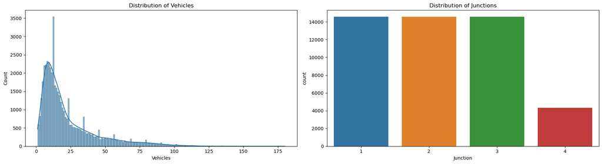

```python
plt.figure(figsize=(18, 5))

# Vehicles distribution
plt.subplot(1, 2, 1)
sns.histplot(data['Vehicles'], kde=True)
plt.title('Distribution of Vehicles')

# Junction distribution
plt.subplot(1, 2, 2)
sns.countplot(x=data['Junction'])
plt.title('Distribution of Junctions')

plt.tight_layout()
plt.show()
```

The distribution of Vehicles shows a right-skewed pattern, indicating that lower traffic volumes occur more frequently but there are periods with exceptionally high traffic.

The Junction distribution plot indicates varying frequencies of observations per junction, with junctions 1, 2, and 3 being more commonly observed than junction 4.

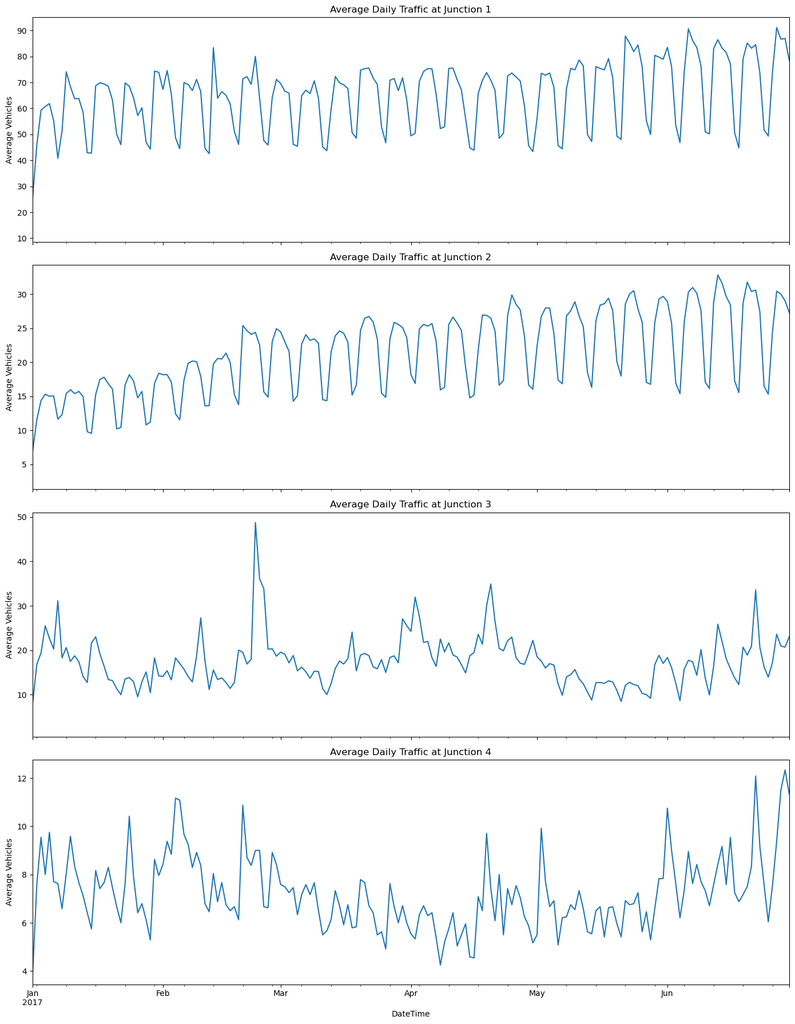

```python
# Plotting the time series for each Junction
fig, axes = plt.subplots(nrows=4, ncols=1, figsize=(14, 18), sharex=True)
for i, junction in enumerate(data['Junction'].unique(), 1):
    temp_data = data[data['Junction'] == junction]['Vehicles'].resample('D').mean()
    temp_data.plot(ax=axes[i-1], title=f'Average Daily Traffic at Junction {junction}')
    axes[i-1].set_ylabel('Average Vehicles')

plt.tight_layout()
plt.show()
```

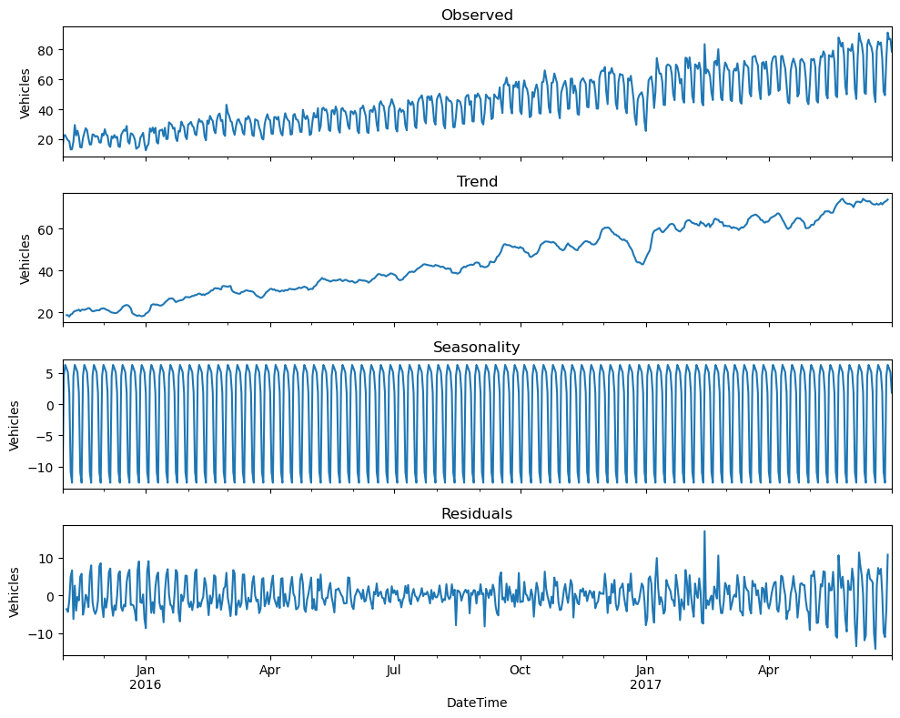

```python
# Decompose the series for Junction 1 as an example
example_series = data[data['Junction'] == 1]['Vehicles'].resample('D').mean()
decomposition = seasonal_decompose(example_series, model='additive', period=7)

# Plot the decomposed components
fig, ax = plt.subplots(nrows=4, ncols=1, figsize=(10, 8), sharex=True)
decomposition.observed.plot(ax=ax[0], title='Observed')
decomposition.trend.plot(ax=ax[1], title='Trend')
decomposition.seasonal.plot(ax=ax[2], title='Seasonality')
decomposition.resid.plot(ax=ax[3], title='Residuals')
ax[0].set_ylabel('Vehicles')
ax[1].set_ylabel('Vehicles')
ax[2].set_ylabel('Vehicles')
ax[3].set_ylabel('Vehicles')
plt.tight_layout()
plt.show()
```

## Minor Question 1

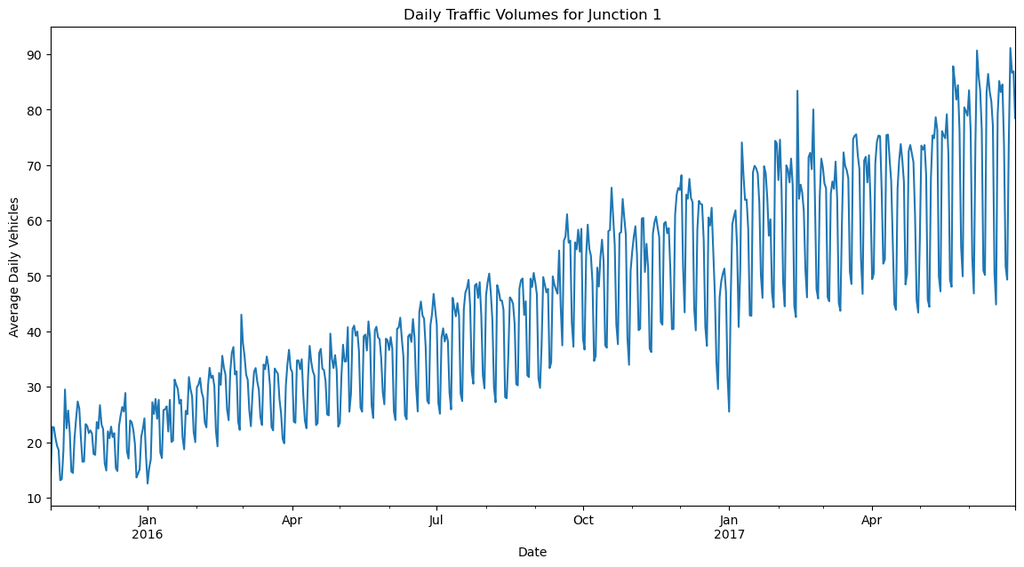

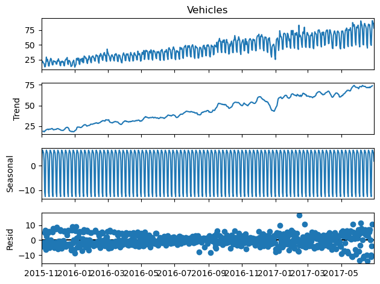

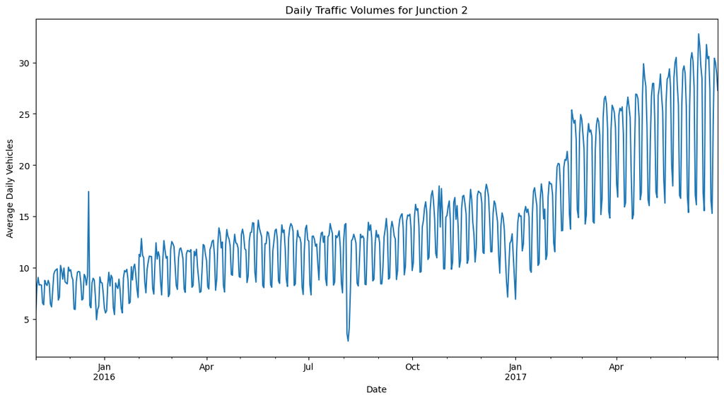

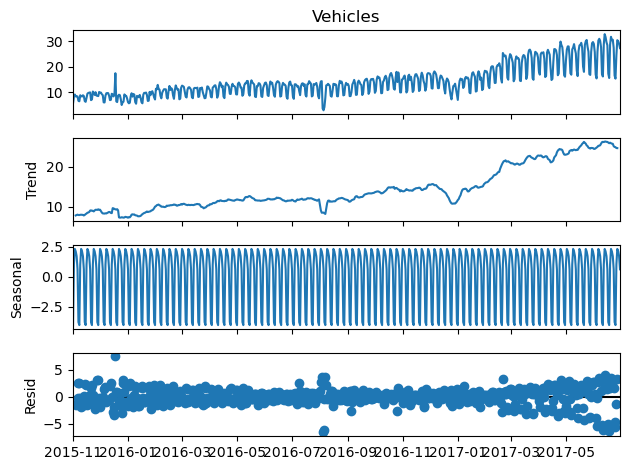

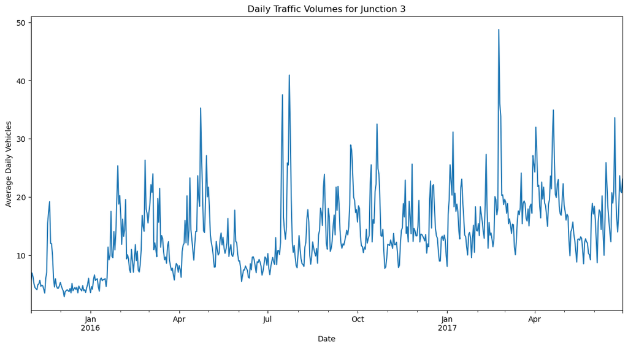

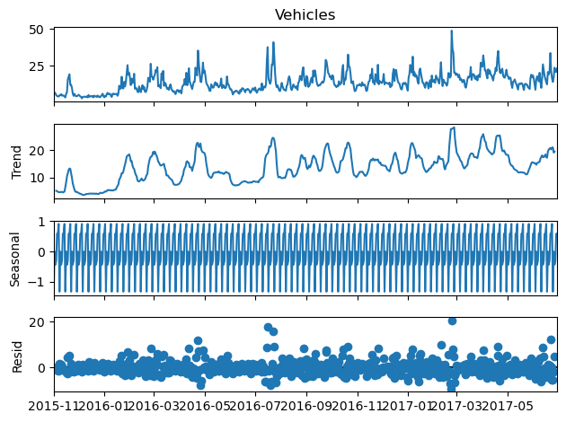

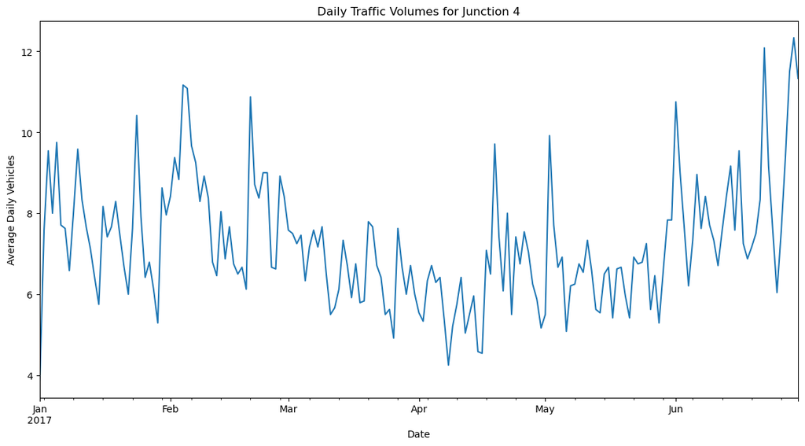

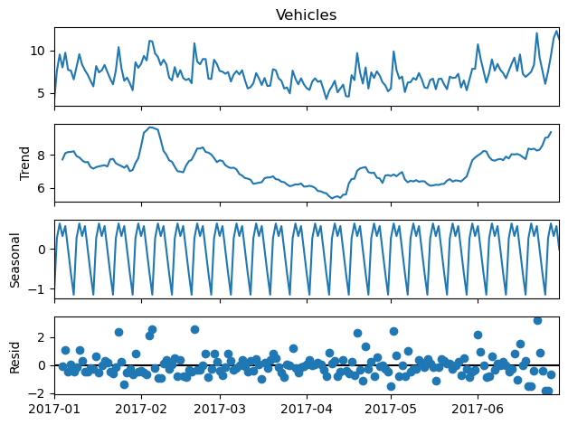

```python
for junction in data['Junction'].unique():
    plt.figure(figsize=(14, 7))
    junction_data = data[data['Junction'] == junction]['Vehicles'].resample('D').mean()

    junction_data.plot(title=f'Daily Traffic Volumes for Junction {junction}')
    plt.xlabel('Date')
    plt.ylabel('Average Daily Vehicles')
    plt.show()

    decomposition = seasonal_decompose(junction_data, model='additive')
    decomposition.plot()
    plt.show()
```

For junction 1:  
The trend component of the data shows a general increase over time, suggesting a long-term rise in traffic volumes at this junction. This could be due to various factors such as urban development, increases in population, or changes in road infrastructure around this junction.  
The seasonal component exhibits very regular, repeating patterns, indicating strong seasonal effects. This regularity might represent weekly cycles (such as higher traffic on weekdays and lower on weekends), or it could represent daily cycles (higher during rush hours and lower at other times). Given the periodicity and regularity, the patterns are likely linked to consistent daily human activities and commuting behaviors.

For junction 2:  
The trend component displays a clear upward trajectory, indicating a long-term increase in traffic volume at this junction. Unlike Junction 3, the trend here is smoother, suggesting fewer fluctuations from external factors, and a more steady increase likely driven by continuous area development or increasing population density.  
The seasonal pattern is extremely regular and strong, much like in Junctions 1 and 3, with no major deviations in the amplitude or frequency of the seasonal peaks. This pattern is indicative of consistent daily or weekly traffic cycles, such as morning and evening rush hours, which are typical in urban settings.

## Minor Question 2

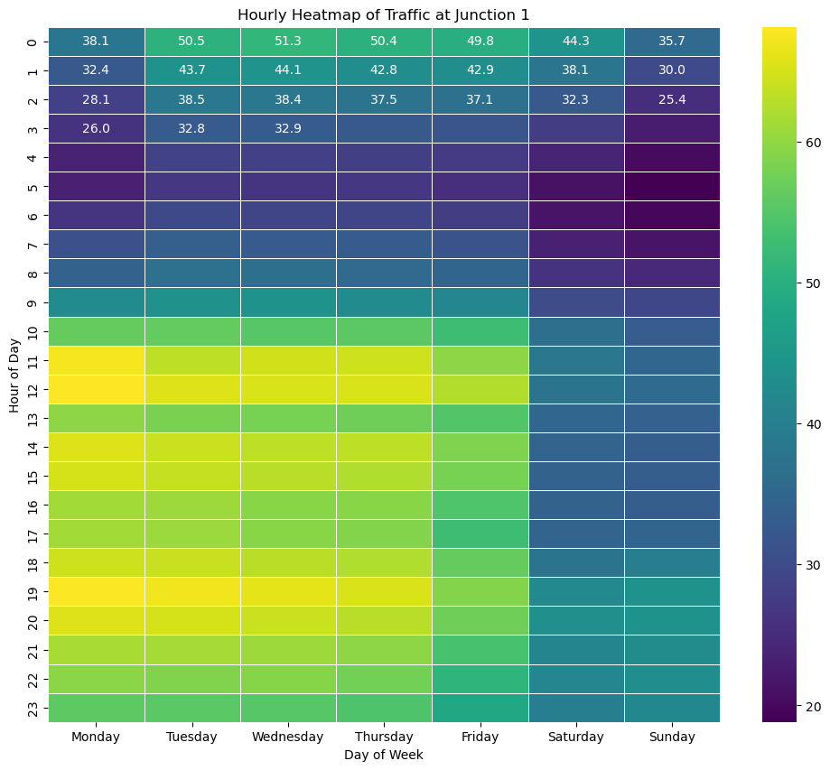

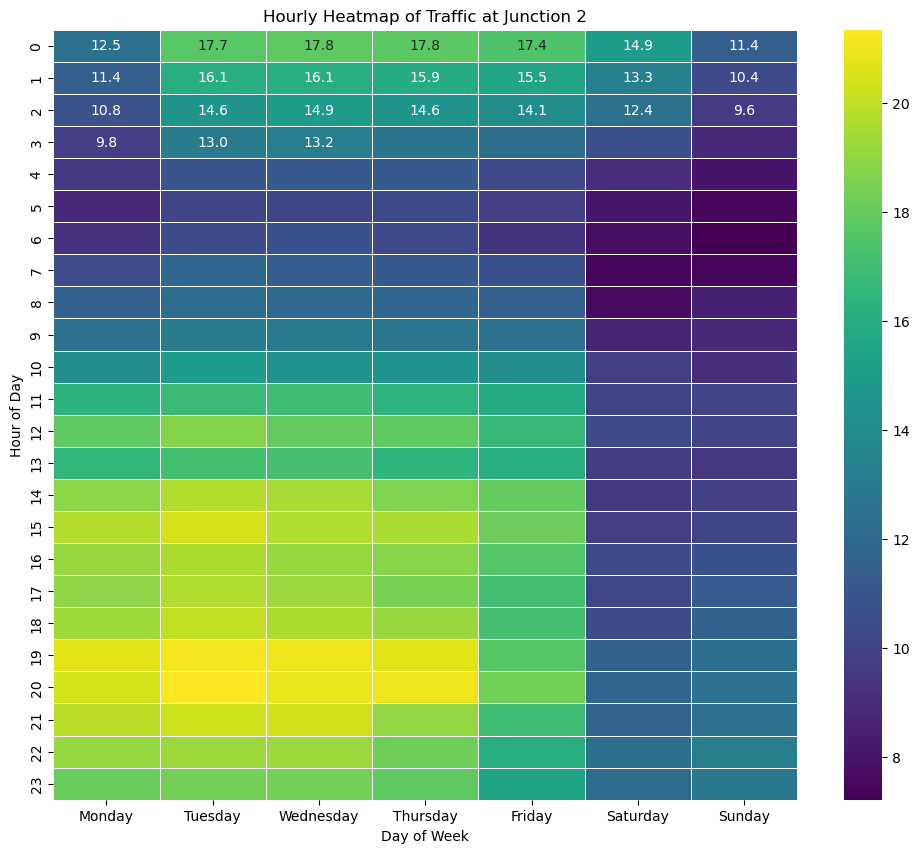

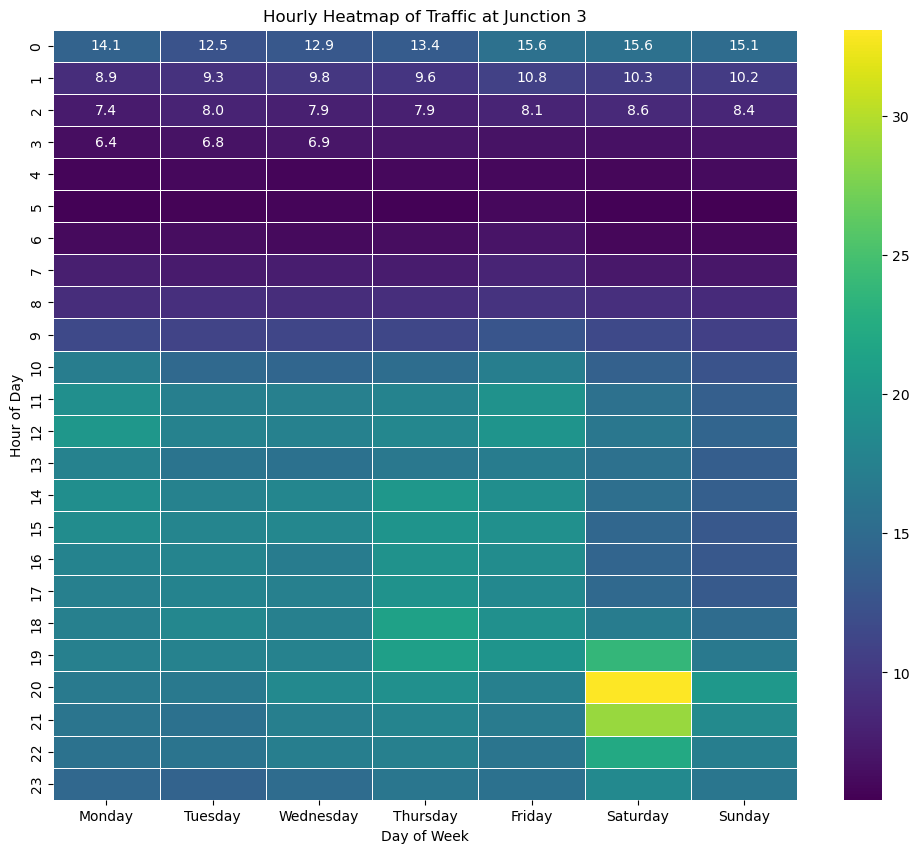

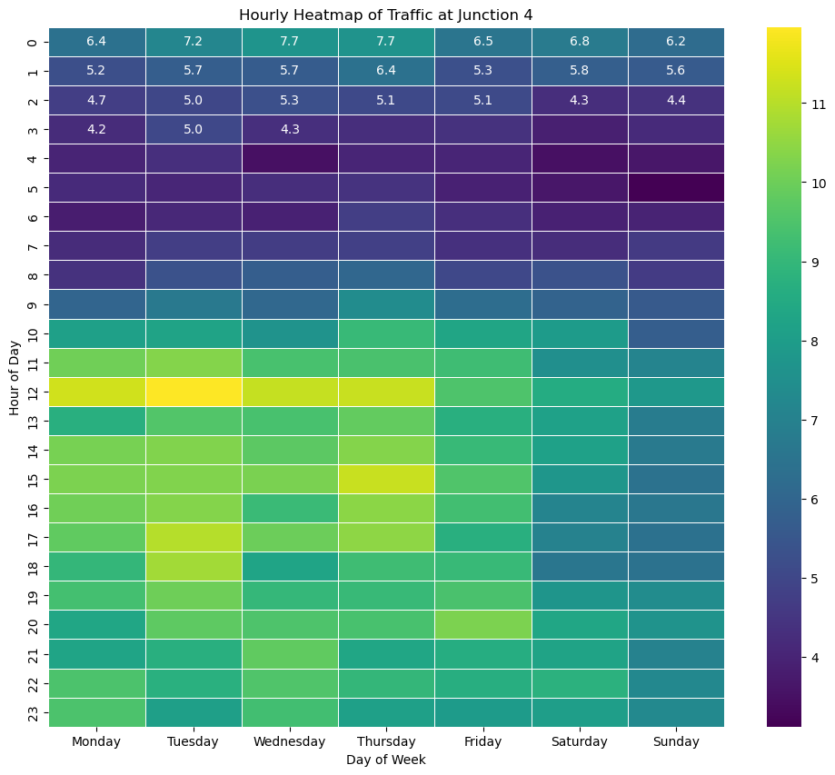

```python
for junction in data['Junction'].unique():
    junction_data = data[data['Junction'] == junction]['Vehicles'].resample('H').mean()

    heatmap_data = junction_data.groupby([junction_data.index.hour, junction_data.index.dayofweek]).mean().unstack()

    day_names = ['Monday', 'Tuesday', 'Wednesday', 'Thursday', 'Friday', 'Saturday', 'Sunday']
    heatmap_data.columns = day_names

    plt.figure(figsize=(12, 10))
    sns.heatmap(heatmap_data, cmap='viridis', annot=True, fmt=".1f", linewidths=.5)
    plt.title(f'Hourly Heatmap of Traffic at Junction {junction}')
    plt.xlabel('Day of Week')
    plt.ylabel('Hour of Day')
    plt.show()
```

For junction 1:  
From the heatmap, it is evident that traffic volumes are highest during morning/afternoon hours (around 11-12 and 13-15) across all weekdays. This is likely associated with morning commutes to work or school and lunch hours. There is also a notable increase in traffic in the late afternoon to early evening (around 18-20), which coincides with the typical end of the workday, again across Monday to Friday. Weekdays generally show higher traffic volumes during typical rush hour periods compared to weekends. On weekends, traffic distribution is more even throughout the day, with lower overall volumes, especially in the early mornings.

For junction 2:  
From the heatmap, it is evident that traffic volumes are highest the late afternoon to early evening (around 18-20), which coincides with the typical end of the workday, again across Monday to Friday. There is also a notable increase in traffic in the early afternoon (14-17), which corresponds to lunch hour and early leave from work. Weekdays generally show higher traffic volumes during typical rush hour periods compared to weekends. On weekends, traffic distribution is more even throughout the day, with lower overall volumes, especially in the early mornings.

For junction 3:  
From the heatmap, it is evident that traffic volumes are highest the early evening (around 20). Unlike the other junctions, the people in this junction either rarely drives using their individual vehicles or prefers public transport such as trains. However, there is an unusually high traffic at around 20 (8 PM) on Saturday.

## Model - Main Question

```python
# Initialize a dictionary to store models and forecasts
models = {}
forecasts = {}
rmse_scores = {}
```

```
Junction: 1
 ARIMA(0,0,0)(0,0,0)[7] intercept   : AIC=-3204.008, Time=0.08 sec
 ARIMA(0,0,0)(0,0,1)[7] intercept   : AIC=-3253.929, Time=0.27 sec
 ARIMA(0,0,0)(0,0,2)[7] intercept   : AIC=-3262.405, Time=1.10 sec
 ARIMA(0,0,0)(1,0,0)[7] intercept   : AIC=-3270.703, Time=0.28 sec
 ARIMA(0,0,0)(1,0,1)[7] intercept   : AIC=inf, Time=0.70 sec
 ARIMA(0,0,0)(1,0,2)[7] intercept   : AIC=-3284.896, Time=1.86 sec
 ARIMA(0,0,0)(2,0,0)[7] intercept   : AIC=-3280.724, Time=0.87 sec
 ARIMA(0,0,0)(2,0,1)[7] intercept   : AIC=-3343.965, Time=1.35 sec
 ARIMA(0,0,0)(2,0,2)[7] intercept   : AIC=inf, Time=2.36 sec
 ARIMA(0,0,1)(0,0,0)[7] intercept   : AIC=-3318.058, Time=0.48 sec
 ARIMA(0,0,1)(0,0,1)[7] intercept   : AIC=-3410.062, Time=1.09 sec
 ARIMA(0,0,1)(0,0,2)[7] intercept   : AIC=-3429.633, Time=2.13 sec
 ARIMA(0,0,1)(1,0,0)[7] intercept   : AIC=-3466.176, Time=1.10 sec
 ARIMA(0,0,1)(1,0,1)[7] intercept   : AIC=-3513.786, Time=1.56 sec
 ARIMA(0,0,1)(1,0,2)[7] intercept   : AIC=-3495.973, Time=2.05 sec
 ARIMA(0,0,1)(2,0,0)[7] intercept   : AIC=-3477.431, Time=0.94 sec
 ARIMA(0,0,1)(2,0,1)[7] intercept   : AIC=-3488.531, Time=1.37 sec
 ARIMA(0,0,1)(2,0,2)[7] intercept   : AIC=-3499.536, Time=1.35 sec
 ARIMA(0,0,2)(0,0,0)[7] intercept   : AIC=-3368.391, Time=0.38 sec
 ARIMA(0,0,2)(0,0,1)[7] intercept   : AIC=-3436.451, Time=0.82 sec
 ARIMA(0,0,2)(0,0,2)[7] intercept   : AIC=-3456.007, Time=2.05 sec
 ARIMA(0,0,2)(1,0,0)[7] intercept   : AIC=-3469.672, Time=0.38 sec
 ARIMA(0,0,2)(1,0,1)[7] intercept   : AIC=-3481.952, Time=0.94 sec
 ARIMA(0,0,2)(1,0,2)[7] intercept   : AIC=-3477.634, Time=1.57 sec
 ARIMA(0,0,2)(2,0,0)[7] intercept   : AIC=-3498.061, Time=1.39 sec
 ARIMA(0,0,2)(2,0,1)[7] intercept   : AIC=-3502.299, Time=1.35 sec
 ARIMA(0,0,2)(2,0,2)[7] intercept   : AIC=-3434.420, Time=1.59 sec
 ARIMA(0,0,3)(0,0,0)[7] intercept   : AIC=-3359.254, Time=0.20 sec
 ARIMA(0,0,3)(0,0,1)[7] intercept   : AIC=-3423.624, Time=0.77 sec
 ARIMA(0,0,3)(0,0,2)[7] intercept   : AIC=-3427.354, Time=0.87 sec
 ARIMA(0,0,3)(1,0,0)[7] intercept   : AIC=-3477.782, Time=0.76 sec
 ARIMA(0,0,3)(1,0,1)[7] intercept   : AIC=-3459.212, Time=1.05 sec
 ARIMA(0,0,3)(1,0,2)[7] intercept   : AIC=-3436.989, Time=1.10 sec
 ARIMA(0,0,3)(2,0,0)[7] intercept   : AIC=-3490.942, Time=0.60 sec
 ARIMA(0,0,3)(2,0,1)[7] intercept   : AIC=-3480.144, Time=0.67 sec
 ARIMA(0,0,3)(2,0,2)[7] intercept   : AIC=-3450.613, Time=1.93 sec
 ARIMA(1,0,0)(0,0,0)[7] intercept   : AIC=-3229.112, Time=0.09 sec
 ARIMA(1,0,0)(0,0,1)[7] intercept   : AIC=-3309.661, Time=0.48 sec
 ARIMA(1,0,0)(0,0,2)[7] intercept   : AIC=-3331.806, Time=1.50 sec
```

[output cut: 93 more lines]

```
 ARIMA(3,0,2)(2,0,0)[7] intercept   : AIC=-3487.106, Time=4.76 sec
 ARIMA(3,0,2)(2,0,1)[7] intercept   : AIC=-3486.196, Time=5.54 sec
 ARIMA(3,0,2)(2,0,2)[7] intercept   : AIC=-3507.882, Time=5.61 sec
 ARIMA(3,0,3)(0,0,0)[7] intercept   : AIC=-3427.816, Time=1.74 sec
 ARIMA(3,0,3)(0,0,1)[7] intercept   : AIC=-3442.823, Time=3.18 sec
 ARIMA(3,0,3)(0,0,2)[7] intercept   : AIC=-3441.507, Time=4.55 sec
 ARIMA(3,0,3)(1,0,0)[7] intercept   : AIC=-3445.228, Time=1.48 sec
 ARIMA(3,0,3)(1,0,1)[7] intercept   : AIC=-3459.753, Time=2.06 sec
 ARIMA(3,0,3)(1,0,2)[7] intercept   : AIC=-3482.601, Time=8.45 sec
 ARIMA(3,0,3)(2,0,0)[7] intercept   : AIC=-3487.690, Time=4.61 sec
 ARIMA(3,0,3)(2,0,1)[7] intercept   : AIC=-3493.989, Time=5.23 sec
 ARIMA(3,0,3)(2,0,2)[7] intercept   : AIC=-3419.795, Time=3.17 sec

Best model:  ARIMA(0,0,1)(1,0,1)[7] intercept
Total fit time: 346.830 seconds
```

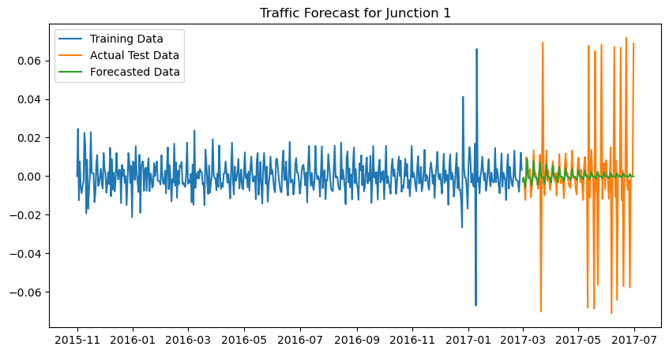

```
RMSE for Junction 1: 0.024647377462875545

Junction: 2
 ARIMA(0,0,0)(0,0,0)[7] intercept   : AIC=-2754.120, Time=0.16 sec
 ARIMA(0,0,0)(0,0,1)[7] intercept   : AIC=-2765.404, Time=0.44 sec
 ARIMA(0,0,0)(0,0,2)[7] intercept   : AIC=-2766.329, Time=1.62 sec
 ARIMA(0,0,0)(1,0,0)[7] intercept   : AIC=-2768.201, Time=0.39 sec
 ARIMA(0,0,0)(1,0,1)[7] intercept   : AIC=inf, Time=1.37 sec
 ARIMA(0,0,0)(1,0,2)[7] intercept   : AIC=-2805.954, Time=2.54 sec
 ARIMA(0,0,0)(2,0,0)[7] intercept   : AIC=-2771.088, Time=0.33 sec
 ARIMA(0,0,0)(2,0,1)[7] intercept   : AIC=-2816.453, Time=2.31 sec
 ARIMA(0,0,0)(2,0,2)[7] intercept   : AIC=inf, Time=4.53 sec
 ARIMA(0,0,1)(0,0,0)[7] intercept   : AIC=-2915.325, Time=0.41 sec
 ARIMA(0,0,1)(0,0,1)[7] intercept   : AIC=-2950.200, Time=1.52 sec
 ARIMA(0,0,1)(0,0,2)[7] intercept   : AIC=-2954.908, Time=2.50 sec
 ARIMA(0,0,1)(1,0,0)[7] intercept   : AIC=-2961.737, Time=1.33 sec
 ARIMA(0,0,1)(1,0,1)[7] intercept   : AIC=inf, Time=2.29 sec
 ARIMA(0,0,1)(1,0,2)[7] intercept   : AIC=-2963.140, Time=3.03 sec
 ARIMA(0,0,1)(2,0,0)[7] intercept   : AIC=-2964.582, Time=2.33 sec
 ARIMA(0,0,1)(2,0,1)[7] intercept   : AIC=-2976.071, Time=2.75 sec
 ARIMA(0,0,1)(2,0,2)[7] intercept   : AIC=-3006.176, Time=3.44 sec
 ARIMA(0,0,2)(0,0,0)[7] intercept   : AIC=-2925.459, Time=0.48 sec
 ARIMA(0,0,2)(0,0,1)[7] intercept   : AIC=-2937.135, Time=0.70 sec
 ARIMA(0,0,2)(0,0,2)[7] intercept   : AIC=-2962.829, Time=2.89 sec
 ARIMA(0,0,2)(1,0,0)[7] intercept   : AIC=-2944.124, Time=0.65 sec
 ARIMA(0,0,2)(1,0,1)[7] intercept   : AIC=-2994.340, Time=2.16 sec
 ARIMA(0,0,2)(1,0,2)[7] intercept   : AIC=-2959.159, Time=2.27 sec
 ARIMA(0,0,2)(2,0,0)[7] intercept   : AIC=-2967.822, Time=1.95 sec
 ARIMA(0,0,2)(2,0,1)[7] intercept   : AIC=-2967.673, Time=3.42 sec
 ARIMA(0,0,2)(2,0,2)[7] intercept   : AIC=-2976.645, Time=7.92 sec
 ARIMA(0,0,3)(0,0,0)[7] intercept   : AIC=-2930.587, Time=1.09 sec
 ARIMA(0,0,3)(0,0,1)[7] intercept   : AIC=-2957.897, Time=2.28 sec
 ARIMA(0,0,3)(0,0,2)[7] intercept   : AIC=-2962.295, Time=3.66 sec
 ARIMA(0,0,3)(1,0,0)[7] intercept   : AIC=-2965.682, Time=1.47 sec
 ARIMA(0,0,3)(1,0,1)[7] intercept   : AIC=-2971.747, Time=2.64 sec
 ARIMA(0,0,3)(1,0,2)[7] intercept   : AIC=-2969.572, Time=4.51 sec
 ARIMA(0,0,3)(2,0,0)[7] intercept   : AIC=-2971.119, Time=3.34 sec
 ARIMA(0,0,3)(2,0,1)[7] intercept   : AIC=-2965.565, Time=4.20 sec
 ARIMA(0,0,3)(2,0,2)[7] intercept   : AIC=-2955.190, Time=5.15 sec
 ARIMA(1,0,0)(0,0,0)[7] intercept   : AIC=-2796.367, Time=0.28 sec
```

[output cut: 95 more lines]

```
 ARIMA(3,0,2)(2,0,0)[7] intercept   : AIC=-2965.466, Time=4.70 sec
 ARIMA(3,0,2)(2,0,1)[7] intercept   : AIC=-2971.000, Time=5.37 sec
 ARIMA(3,0,2)(2,0,2)[7] intercept   : AIC=-2967.490, Time=5.57 sec
 ARIMA(3,0,3)(0,0,0)[7] intercept   : AIC=-2893.634, Time=1.35 sec
 ARIMA(3,0,3)(0,0,1)[7] intercept   : AIC=-2914.579, Time=2.37 sec
 ARIMA(3,0,3)(0,0,2)[7] intercept   : AIC=-2912.203, Time=3.71 sec
 ARIMA(3,0,3)(1,0,0)[7] intercept   : AIC=-2927.414, Time=2.25 sec
 ARIMA(3,0,3)(1,0,1)[7] intercept   : AIC=-2917.953, Time=2.69 sec
 ARIMA(3,0,3)(1,0,2)[7] intercept   : AIC=-2914.454, Time=4.17 sec
 ARIMA(3,0,3)(2,0,0)[7] intercept   : AIC=-2934.959, Time=1.80 sec
 ARIMA(3,0,3)(2,0,1)[7] intercept   : AIC=-2928.748, Time=2.26 sec
 ARIMA(3,0,3)(2,0,2)[7] intercept   : AIC=-2917.306, Time=4.75 sec

Best model:  ARIMA(0,0,1)(2,0,2)[7] intercept
Total fit time: 427.367 seconds
```

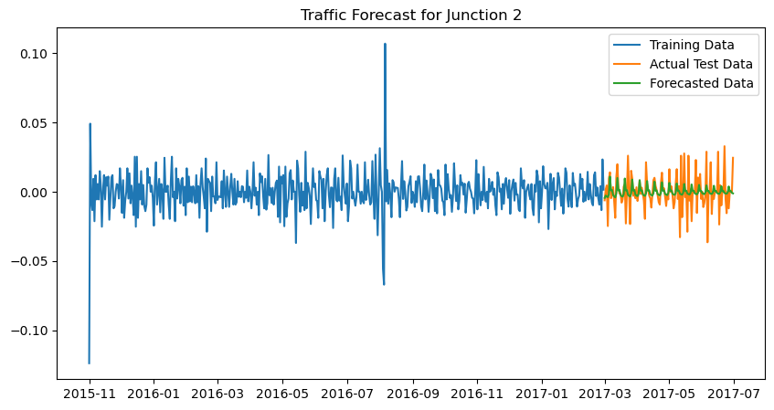

```
RMSE for Junction 2: 0.01207887459194471

Junction: 3
 ARIMA(0,0,0)(0,0,0)[7] intercept   : AIC=-2441.097, Time=0.13 sec
 ARIMA(0,0,0)(0,0,1)[7] intercept   : AIC=-2439.215, Time=0.95 sec
 ARIMA(0,0,0)(0,0,2)[7] intercept   : AIC=-2437.312, Time=0.67 sec
 ARIMA(0,0,0)(1,0,0)[7] intercept   : AIC=-2439.219, Time=0.24 sec
 ARIMA(0,0,0)(1,0,1)[7] intercept   : AIC=-2437.243, Time=0.62 sec
 ARIMA(0,0,0)(1,0,2)[7] intercept   : AIC=-2435.302, Time=0.91 sec
 ARIMA(0,0,0)(2,0,0)[7] intercept   : AIC=-2437.277, Time=0.47 sec
 ARIMA(0,0,0)(2,0,1)[7] intercept   : AIC=-2435.299, Time=2.40 sec
 ARIMA(0,0,0)(2,0,2)[7] intercept   : AIC=-2433.297, Time=1.34 sec
 ARIMA(0,0,1)(0,0,0)[7] intercept   : AIC=-2533.549, Time=0.40 sec
 ARIMA(0,0,1)(0,0,1)[7] intercept   : AIC=-2532.265, Time=1.23 sec
 ARIMA(0,0,1)(0,0,2)[7] intercept   : AIC=-2530.435, Time=2.12 sec
 ARIMA(0,0,1)(1,0,0)[7] intercept   : AIC=-2532.238, Time=1.06 sec
 ARIMA(0,0,1)(1,0,1)[7] intercept   : AIC=-2530.153, Time=1.06 sec
 ARIMA(0,0,1)(1,0,2)[7] intercept   : AIC=-2528.415, Time=2.52 sec
 ARIMA(0,0,1)(2,0,0)[7] intercept   : AIC=-2530.416, Time=2.27 sec
 ARIMA(0,0,1)(2,0,1)[7] intercept   : AIC=-2528.396, Time=2.07 sec
 ARIMA(0,0,1)(2,0,2)[7] intercept   : AIC=-2526.448, Time=2.06 sec
 ARIMA(0,0,2)(0,0,0)[7] intercept   : AIC=-2540.566, Time=0.62 sec
 ARIMA(0,0,2)(0,0,1)[7] intercept   : AIC=-2539.195, Time=1.36 sec
 ARIMA(0,0,2)(0,0,2)[7] intercept   : AIC=-2537.758, Time=2.00 sec
 ARIMA(0,0,2)(1,0,0)[7] intercept   : AIC=-2539.150, Time=0.98 sec
 ARIMA(0,0,2)(1,0,1)[7] intercept   : AIC=-2537.016, Time=2.84 sec
 ARIMA(0,0,2)(1,0,2)[7] intercept   : AIC=-2535.750, Time=3.39 sec
 ARIMA(0,0,2)(2,0,0)[7] intercept   : AIC=-2537.714, Time=3.08 sec
 ARIMA(0,0,2)(2,0,1)[7] intercept   : AIC=-2535.719, Time=2.79 sec
 ARIMA(0,0,2)(2,0,2)[7] intercept   : AIC=-2533.775, Time=4.14 sec
 ARIMA(0,0,3)(0,0,0)[7] intercept   : AIC=-2547.910, Time=1.05 sec
 ARIMA(0,0,3)(0,0,1)[7] intercept   : AIC=-2546.315, Time=1.99 sec
 ARIMA(0,0,3)(0,0,2)[7] intercept   : AIC=-2545.302, Time=3.46 sec
 ARIMA(0,0,3)(1,0,0)[7] intercept   : AIC=-2546.436, Time=1.55 sec
 ARIMA(0,0,3)(1,0,1)[7] intercept   : AIC=-2543.949, Time=2.04 sec
 ARIMA(0,0,3)(1,0,2)[7] intercept   : AIC=-2543.254, Time=4.20 sec
 ARIMA(0,0,3)(2,0,0)[7] intercept   : AIC=-2544.917, Time=2.35 sec
 ARIMA(0,0,3)(2,0,1)[7] intercept   : AIC=-2542.710, Time=2.38 sec
 ARIMA(0,0,3)(2,0,2)[7] intercept   : AIC=-2541.264, Time=4.84 sec
 ARIMA(1,0,0)(0,0,0)[7] intercept   : AIC=-2503.055, Time=0.26 sec
```

[output cut: 95 more lines]

```
 ARIMA(3,0,2)(2,0,0)[7] intercept   : AIC=-2543.144, Time=2.33 sec
 ARIMA(3,0,2)(2,0,1)[7] intercept   : AIC=-2541.047, Time=2.77 sec
 ARIMA(3,0,2)(2,0,2)[7] intercept   : AIC=-2538.624, Time=3.02 sec
 ARIMA(3,0,3)(0,0,0)[7] intercept   : AIC=-2548.115, Time=0.72 sec
 ARIMA(3,0,3)(0,0,1)[7] intercept   : AIC=-2545.493, Time=1.67 sec
 ARIMA(3,0,3)(0,0,2)[7] intercept   : AIC=-2543.923, Time=3.19 sec
 ARIMA(3,0,3)(1,0,0)[7] intercept   : AIC=-2545.376, Time=1.63 sec
 ARIMA(3,0,3)(1,0,1)[7] intercept   : AIC=-2543.366, Time=1.81 sec
 ARIMA(3,0,3)(1,0,2)[7] intercept   : AIC=-2541.946, Time=2.95 sec
 ARIMA(3,0,3)(2,0,0)[7] intercept   : AIC=-2543.853, Time=2.20 sec
 ARIMA(3,0,3)(2,0,1)[7] intercept   : AIC=-2541.771, Time=2.61 sec
 ARIMA(3,0,3)(2,0,2)[7] intercept   : AIC=-2539.903, Time=2.85 sec

Best model:  ARIMA(2,0,1)(0,0,0)[7] intercept
Total fit time: 261.641 seconds
```

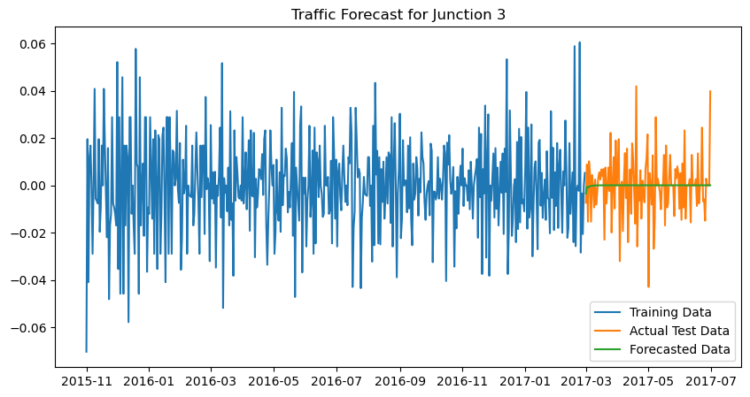

```
RMSE for Junction 3: 0.012884314863096082

Junction: 4
 ARIMA(0,0,0)(0,0,0)[7] intercept   : AIC=-725.113, Time=0.02 sec
 ARIMA(0,0,0)(0,0,1)[7] intercept   : AIC=-723.359, Time=0.05 sec
 ARIMA(0,0,0)(0,0,2)[7] intercept   : AIC=-726.739, Time=0.17 sec
 ARIMA(0,0,0)(1,0,0)[7] intercept   : AIC=-723.466, Time=0.06 sec
 ARIMA(0,0,0)(1,0,1)[7] intercept   : AIC=-721.646, Time=0.12 sec
 ARIMA(0,0,0)(1,0,2)[7] intercept   : AIC=-727.748, Time=0.43 sec
 ARIMA(0,0,0)(2,0,0)[7] intercept   : AIC=-727.548, Time=0.22 sec
 ARIMA(0,0,0)(2,0,1)[7] intercept   : AIC=-728.840, Time=0.58 sec
 ARIMA(0,0,0)(2,0,2)[7] intercept   : AIC=-725.660, Time=0.41 sec
 ARIMA(0,0,1)(0,0,0)[7] intercept   : AIC=-786.993, Time=0.10 sec
 ARIMA(0,0,1)(0,0,1)[7] intercept   : AIC=-784.997, Time=0.19 sec
 ARIMA(0,0,1)(0,0,2)[7] intercept   : AIC=-783.962, Time=0.28 sec
 ARIMA(0,0,1)(1,0,0)[7] intercept   : AIC=-784.996, Time=0.21 sec
 ARIMA(0,0,1)(1,0,1)[7] intercept   : AIC=-783.032, Time=0.28 sec
 ARIMA(0,0,1)(1,0,2)[7] intercept   : AIC=-782.754, Time=0.50 sec
 ARIMA(0,0,1)(2,0,0)[7] intercept   : AIC=-784.732, Time=0.34 sec
 ARIMA(0,0,1)(2,0,1)[7] intercept   : AIC=inf, Time=0.92 sec
 ARIMA(0,0,1)(2,0,2)[7] intercept   : AIC=-781.765, Time=0.56 sec
 ARIMA(0,0,2)(0,0,0)[7] intercept   : AIC=-786.677, Time=0.18 sec
 ARIMA(0,0,2)(0,0,1)[7] intercept   : AIC=-784.668, Time=0.26 sec
 ARIMA(0,0,2)(0,0,2)[7] intercept   : AIC=-783.891, Time=0.51 sec
 ARIMA(0,0,2)(1,0,0)[7] intercept   : AIC=-784.550, Time=0.25 sec
 ARIMA(0,0,2)(1,0,1)[7] intercept   : AIC=-782.748, Time=0.40 sec
 ARIMA(0,0,2)(1,0,2)[7] intercept   : AIC=-780.966, Time=0.59 sec
 ARIMA(0,0,2)(2,0,0)[7] intercept   : AIC=-785.041, Time=0.59 sec
 ARIMA(0,0,2)(2,0,1)[7] intercept   : AIC=-783.408, Time=0.61 sec
 ARIMA(0,0,2)(2,0,2)[7] intercept   : AIC=-780.989, Time=0.64 sec
 ARIMA(0,0,3)(0,0,0)[7] intercept   : AIC=-791.317, Time=0.07 sec
 ARIMA(0,0,3)(0,0,1)[7] intercept   : AIC=-789.508, Time=0.26 sec
 ARIMA(0,0,3)(0,0,2)[7] intercept   : AIC=-784.895, Time=0.50 sec
 ARIMA(0,0,3)(1,0,0)[7] intercept   : AIC=-789.297, Time=0.10 sec
 ARIMA(0,0,3)(1,0,1)[7] intercept   : AIC=-786.845, Time=0.17 sec
 ARIMA(0,0,3)(1,0,2)[7] intercept   : AIC=-782.866, Time=0.41 sec
 ARIMA(0,0,3)(2,0,0)[7] intercept   : AIC=-791.270, Time=0.62 sec
 ARIMA(0,0,3)(2,0,1)[7] intercept   : AIC=-788.989, Time=0.37 sec
 ARIMA(0,0,3)(2,0,2)[7] intercept   : AIC=-781.984, Time=0.32 sec
 ARIMA(1,0,0)(0,0,0)[7] intercept   : AIC=-764.210, Time=0.06 sec
```

[output cut: 95 more lines]

```
 ARIMA(3,0,2)(2,0,0)[7] intercept   : AIC=-787.354, Time=0.43 sec
 ARIMA(3,0,2)(2,0,1)[7] intercept   : AIC=-784.962, Time=0.39 sec
 ARIMA(3,0,2)(2,0,2)[7] intercept   : AIC=-777.106, Time=0.47 sec
 ARIMA(3,0,3)(0,0,0)[7] intercept   : AIC=-783.914, Time=0.15 sec
 ARIMA(3,0,3)(0,0,1)[7] intercept   : AIC=-784.617, Time=0.85 sec
 ARIMA(3,0,3)(0,0,2)[7] intercept   : AIC=-784.939, Time=1.05 sec
 ARIMA(3,0,3)(1,0,0)[7] intercept   : AIC=-784.730, Time=0.55 sec
 ARIMA(3,0,3)(1,0,1)[7] intercept   : AIC=-782.444, Time=0.58 sec
 ARIMA(3,0,3)(1,0,2)[7] intercept   : AIC=-782.988, Time=0.99 sec
 ARIMA(3,0,3)(2,0,0)[7] intercept   : AIC=-785.062, Time=0.42 sec
 ARIMA(3,0,3)(2,0,1)[7] intercept   : AIC=-783.530, Time=1.00 sec
 ARIMA(3,0,3)(2,0,2)[7] intercept   : AIC=-781.340, Time=1.47 sec

Best model:  ARIMA(2,0,3)(0,0,0)[7] intercept
Total fit time: 67.999 seconds
```

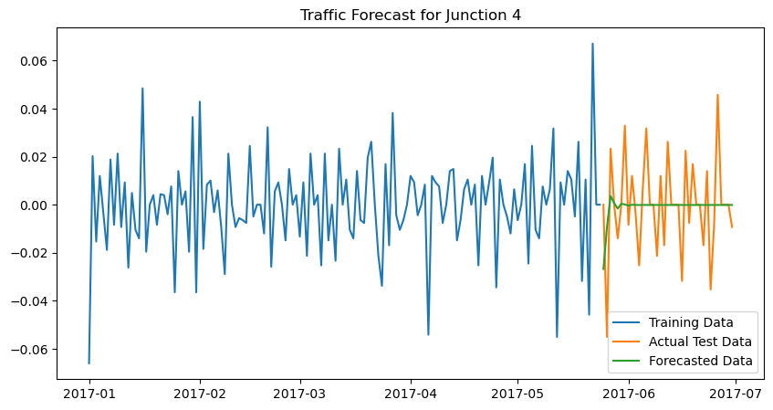

```
RMSE for Junction 4: 0.019267211514046968
```

```python
# Process each junction
for junction in data['Junction'].unique():
    print("Junction: " + str(junction))
    # Extract data for the current junction and resample daily
    junction_data = data[data['Junction'] == junction]['Diff Log Vehicles'].resample('D').mean()

    # Split the data into training and testing sets (80% training, 20% testing)
    split_point = int(len(junction_data) * 0.8)
    train_data, test_data = junction_data[:split_point], junction_data[split_point:]

    # Define custom p, d, q ranges
    p_range = range(0, 4)
    d_range = range(0, 3)
    q_range = range(0, 4)

    # Use auto_arima with constraints on p and q
    sarima_model = auto_arima(train_data, seasonal=True, m=7, start_p=min(p_range), max_p=max(p_range),
                              start_q=min(q_range), max_q=max(q_range), max_order=None,
                              d=min(d_range), max_d=max(d_range), trace=True,
                              error_action='ignore', suppress_warnings=True, stepwise=False,
                              information_criterion='aic')

    # Store the model
    models[junction] = sarima_model

    # Forecast the test set
    n_periods = len(test_data)
    forecast, conf_int = sarima_model.predict(n_periods=n_periods, return_conf_int=True)

    # Store forecasts
    forecasts[junction] = (test_data, forecast, conf_int)

    # Calculate RMSE
    rmse = np.sqrt(mean_squared_error(test_data, forecast))
    rmse_scores[junction] = rmse

    # Plotting the results
    forecast_index = test_data.index
    plt.figure(figsize=(10, 5))
    plt.plot(train_data, label='Training Data')
    plt.plot(test_data, label='Actual Test Data')
    plt.plot(forecast_index, forecast, label='Forecasted Data')
    plt.title(f'Traffic Forecast for Junction {junction}')
    plt.legend()
    plt.show()

    print(f'RMSE for Junction {junction}: {rmse}')
    print()
```

```python
for i in range(1, 5):
    with open(f'junction_{i}_model.pkl', 'wb') as pkl:
        pickle.dump(models[i], pkl)
```

```python
results_df = pd.DataFrame()
for i in range(1, 5):
    results_df[f'junction_{i}_forecast'] = forecasts[i][1]

results_df.to_csv('junction_forecasts.csv', index=False)
```

```python
results_df
```

|  | junction_1_forecast | junction_2_forecast | junction_3_forecast | junction_4_forecast |
| --- | --- | --- | --- | --- |
| 2017-03-01 | -0.002815 | -0.004446 | -0.003379 | NaN |
| 2017-03-02 | -0.000711 | -0.002754 | -0.000588 | NaN |
| 2017-03-03 | -0.002492 | -0.003606 | -0.000856 | NaN |
| 2017-03-04 | -0.005789 | -0.003911 | -0.000475 | NaN |
| 2017-03-05 | 0.000568 | -0.002092 | -0.000345 | NaN |
| ... | ... | ... | ... | ... |
| 2017-06-26 | 0.001238 | 0.003796 | 0.000098 | -0.00011 |
| 2017-06-27 | 0.000119 | 0.000362 | 0.000098 | -0.00011 |
| 2017-06-28 | -0.000051 | 0.000505 | 0.000098 | -0.00011 |
| 2017-06-29 | -0.000020 | -0.000863 | 0.000098 | -0.00011 |
| 2017-06-30 | -0.000224 | -0.001181 | 0.000098 | -0.00011 |

122 rows × 4 columns

```python
rmse_df = pd.DataFrame(list(rmse_scores.items()), columns=['Junction', 'RMSE'])
rmse_df.to_csv('rmse_scores.csv', index=False)
```

```python
rmse_df
```

|  | Junction | RMSE |
| --- | --- | --- |
| 0 | 1 | 0.024647 |
| 1 | 2 | 0.012079 |
| 2 | 3 | 0.012884 |
| 3 | 4 | 0.019267 |

```python
aic_list = []
for i in range(1, len(models) + 1):
    aic_list.append([i, models[i].aic()])
```

```python
aic_df = pd.DataFrame(aic_list, columns=['Junction', 'AIC'])
aic_df.to_csv('aic_scores.csv', index=False)
```

```python
aic_df
```

|  | Junction | AIC |
| --- | --- | --- |
| 0 | 1 | -3513.785534 |
| 1 | 2 | -3006.175793 |
| 2 | 3 | -2550.370095 |
| 3 | 4 | -792.136275 |

## Percentage of Points Within Confidence Interval

```python
# Junction 1
test_data = forecasts[1][0]
conf_int = forecasts[1][2]

((test_data >= conf_int[:, 0]) & (test_data <= conf_int[:, 1])).mean()
```

```
0.8688524590163934
```

```python
# Junction 2
test_data = forecasts[2][0]
conf_int = forecasts[2][2]

((test_data >= conf_int[:, 0]) & (test_data <= conf_int[:, 1])).mean()
```

```
0.9754098360655737
```

```python
# Junction 3
test_data = forecasts[3][0]
conf_int = forecasts[3][2]

((test_data >= conf_int[:, 0]) & (test_data <= conf_int[:, 1])).mean()
```

```
0.9754098360655737
```

```python
# Junction 4
test_data = forecasts[4][0]
conf_int = forecasts[4][2]

((test_data >= conf_int[:, 0]) & (test_data <= conf_int[:, 1])).mean()
```

```
0.9459459459459459
```